# Texts! In! Space!

John Ladd, jrladd.com/slides/texts-in-space

`spacebar` for next slide, `arrow keys` to navigate, `esc`/menu for overview

# What makes texts *similar*?

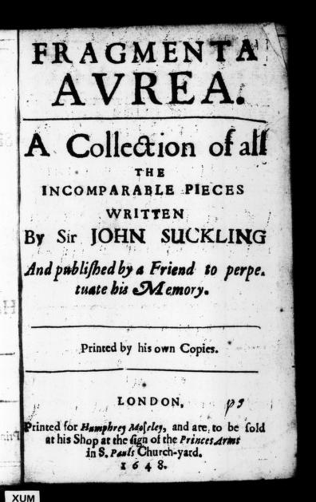

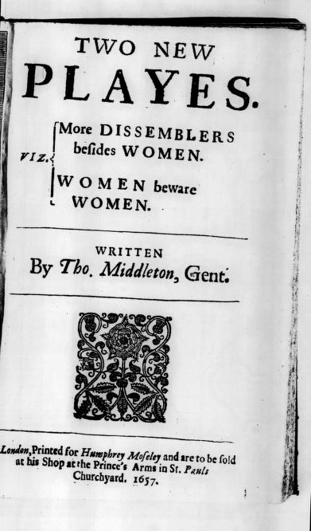

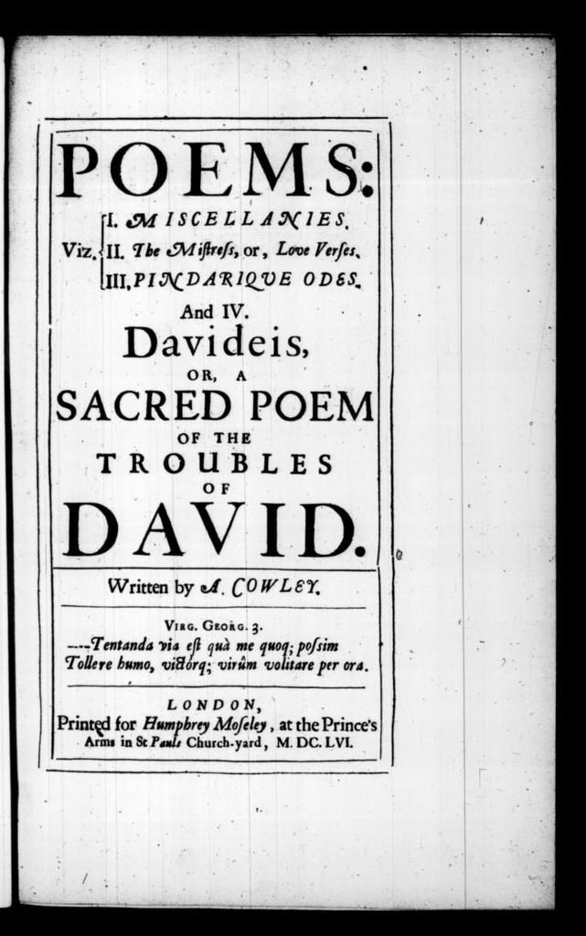

[figure not shown]

## Representing texts as numerical points

## Exploring text corpora

[figure not shown]

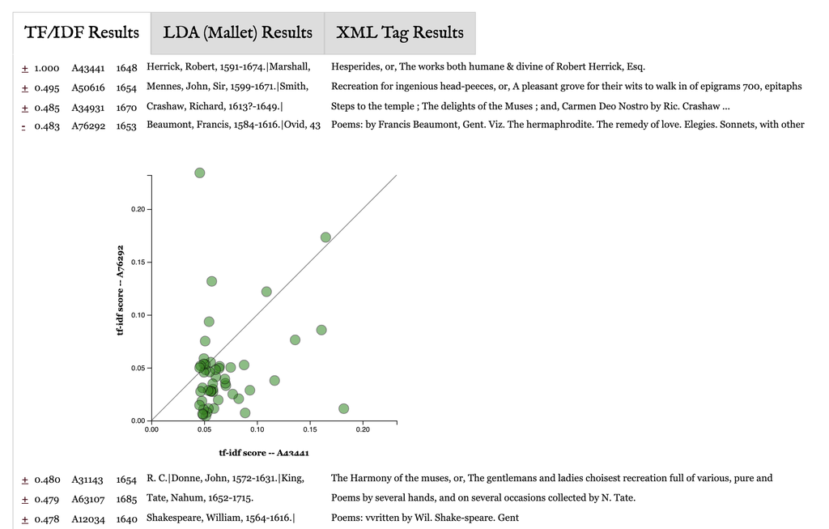

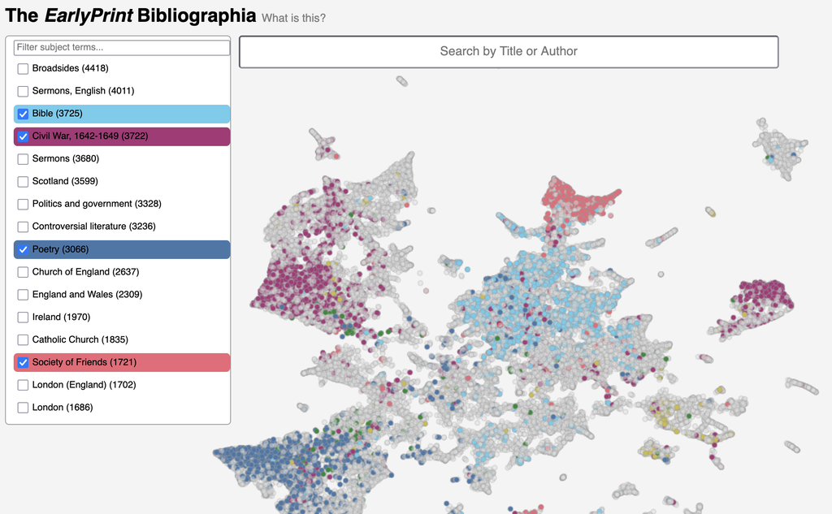

## Finding similar texts by *content*

- Are texts similar when they use **the same words**? (Bag of Words representation)
- Are texts similar when they use **similar words**? (Word & Document embeddings)

# Text Similarity Workflow

1. Normalization and regularization
2. Encode texts with **TF–IDF or Document Embeddings**
3. Calculate similarities with Cosine Distance
4. Visualize with t-SNE: t-distributed Stochastic Neighbor Embedding

## Do we need to normalize spelling?

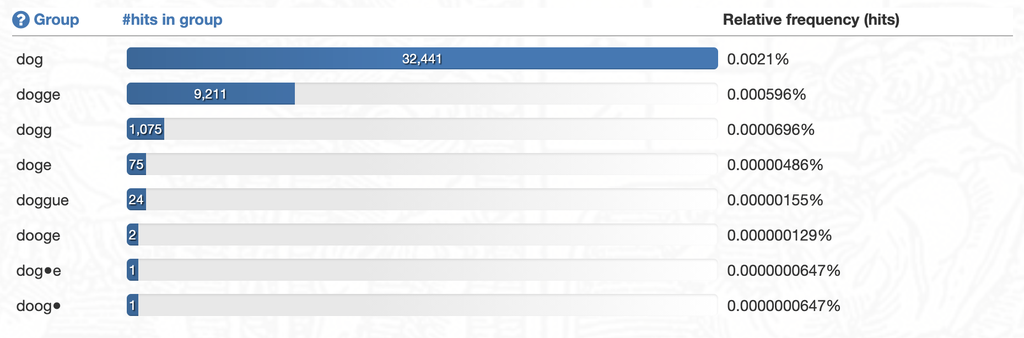

From *EarlyPrint* Corpus Search

For TF–IDF, yes! For document embedding, probably not.

# TF–IDF, or: Word Counts

## Let’s count some words!

austen = “It is a truth universally acknowledged, that a single man in possession of a good fortune must be in want of a wife.”

wharton = “I had the story, bit by bit, from various people, and, as generally happens in such cases, each time it was a different story.”

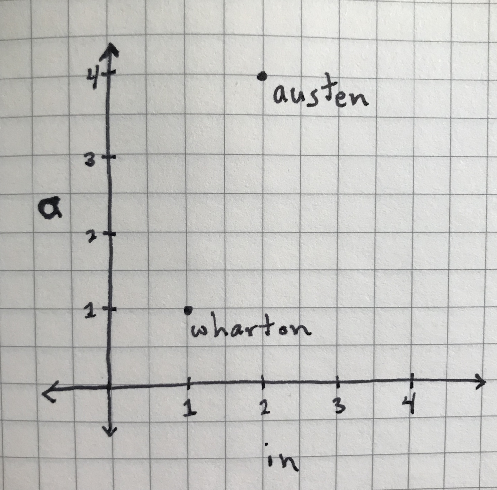

From the [Programming Historian](https://programminghistorian.org/en/lessons/common-similarity-measures).

## We care if a word is distinctive.

Term Frequency–Inverse Document Frequency

$$TF = \frac{Number\,of\,times\,a\,word\,appears}{Total\,words\,in\,the\,text}$$

$$IDF = \ln({\frac{Total\,number\,of\,texts+1}{Number\,of\,texts\,the\,word\,appears\,in}})+1$$

$$TF \times IDF$$

# Document embeddings, or: AI ✨

## Word vs. Context Embedding

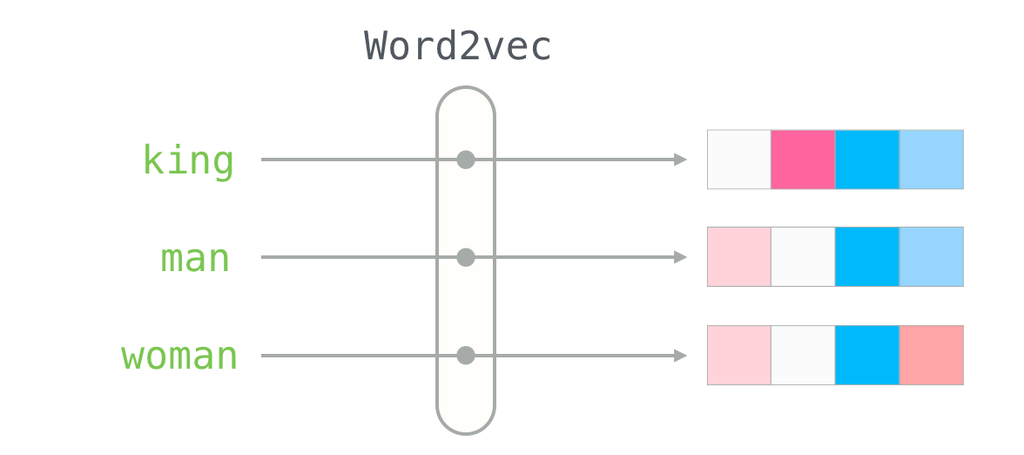

From Jay Alammar’s *The Illustrated Word2Vec*

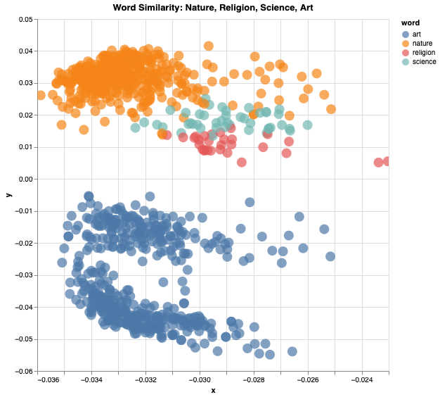

From AI for Humanists, *Measuring Word Similarity with BERT*

## Combine context embeddings into document embeddings.

Uses a specialized LLM called an embedding model.

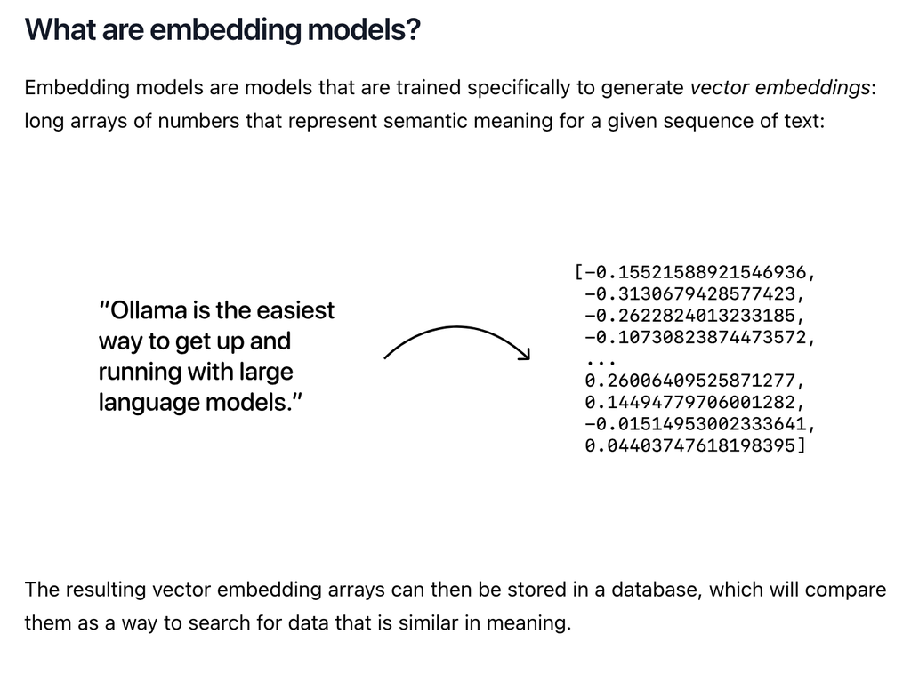

From the [Ollama documentation](https://ollama.com/blog/embedding-models)

# Let’s compare approaches.

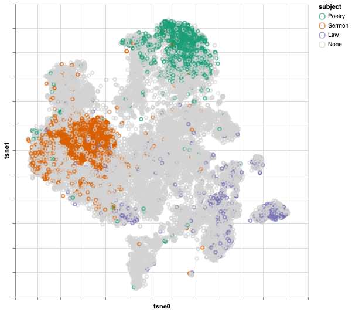

Tf-Idf Wordcounts

## Which to use?

TF–IDF:

- Calculated quickly and cheaply
- Explainable results at every step
- Ignores similar words
- Spelling inconsistencies create spurious connections

Embedding Model:

- Calculations are longer/more expensive
- More difficult to explain/interpret
- Accounts for similarities among words
- More accurate similarities across a longer span of time

## In my project, I used both!

Each approach can validate and support the other.

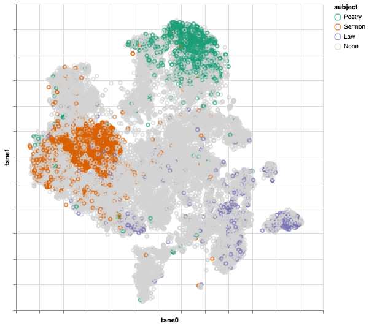

Tf-Idf Wordcounts

LLM document embeddings

[figure not shown]